# Kaggle - Grant Prediction

Step 3: Logistic Regression

Michael Foley

4/14/2020

# Setup

```r
library(tidyverse)
library(caret)
library(mfstylr)
library(flextable)
```

```r
load("./grant_01.RData")
```

# Background

Logistic regression estimates the probability of a particular level of a categorical response variable given a set of predictors. The response levels can be binary, nominal (multiple categories), or ordinal (multiple levels).

The **binary** logistic regression model is

$$y = logit(\pi) = \ln \left( \frac{\pi}{1 - \pi} \right) = X \beta$$

where $\pi$ is the event probability. The model predicts the *log odds* of the response variable. The maximum likelihood estimator maximizes the likelihood function

$$L(\beta; y, X) = \prod_{i=1}^n \pi_i^{y_i}(1 - \pi_i)^{(1-y_i)} = \prod_{i=1}^n\frac{\exp(y_i X_i \beta)}{1 + \exp(X_i \beta)}.$$

There is no closed-form solution, so GLM estimates coefficients with interatively reweighted least squares.

# Model

## Train Control

`train` will tune the model based on the AUC. To construct the ROC curve, train should produce class probabilities rather than class predictions. Set `classProbs = TRUE` to get probabilities. Summary function `twoClassSummary` calculates the area under the ROC curve, the sensitivity, and the specificity.

The data splitting scheme is to build the model on the pre-2008 data, then with the 2008 holdout data, both of which are in the `training` data set, indexed by vector `pre2008` (in the training set) to tune the model.

`savePredictions = TRUE` saves the predictions of the year 2008 grants based on the pre-2008 model (i.e., before the final model is re-fit with all of the training data).

```r
ctrl <- trainControl(
  method = "LGOCV",
  summaryFunction = twoClassSummary,
  classProbs = TRUE,
  index = list(TrainSet = pre2008),
  savePredictions = TRUE
)
```

## Exploring the Model

```r
model_fit <- glm(Class ~ Day, data = training[pre2008, ], family = binomial)
model_fit
```

```
##
## Call:  glm(formula = Class ~ Day, family = binomial, data = training[pre2008,
##     ])
##
## Coefficients:
## (Intercept)          Day
##     -0.3660       0.0267
##
## Degrees of Freedom: 6632 Total (i.e. Null);  6631 Residual
## Null Deviance:       9191
## Residual Deviance: 9103  AIC: 9107
```

```r
success_prob <- 1 - predict(model_fit, newdata = data.frame(Day = c(10, 150, 300, 350)), type = "response")
success_prob
```

```
##            1            2            3            4
## 0.5247346981 0.0256165067 0.0004790980 0.0001261416
```

```r
daySquaredModel <- glm(Class ~ Day + I(Day^2), data = training[pre2008, ], family = binomial)
daySquaredModel
```

```
##
## Call:  glm(formula = Class ~ Day + I(Day^2), family = binomial, data = training[pre2008,
##     ])
##
## Coefficients:
## (Intercept)          Day     I(Day^2)
##   -1.050342     0.165185    -0.004645
##
## Degrees of Freedom: 6632 Total (i.e. Null);  6630 Residual
## Null Deviance:       9191
## Residual Deviance: 8903  AIC: 8909
```

The `rms` (Regression Modeling Strategies) package’s `lrm()` function is similar to `glm()` and includes helper functions. For example, the `rcs()` creates a restricted cubic spline of a predictor.

```r
library(rms)
rcsFit <- lrm(Class ~ rcs(Day), data = training[pre2008,])
rcsFit
```

```
## Logistic Regression Model
##
##  lrm(formula = Class ~ rcs(Day), data = training[pre2008, ])
##
##                        Model Likelihood     Discrimination    Rank Discrim.
##                           Ratio Test           Indexes           Indexes
##  Obs          6633    LR chi2     324.93    R2       0.064    C       0.596
##   successful  3233    d.f.             4    g        0.453    Dxy     0.192
##   unsuccessful3400    Pr(> chi2) <0.0001    gr       1.573    gamma   0.204
##  max |deriv| 1e-10                          gp       0.108    tau-a   0.096
##                                             Brier    0.238
##
##            Coef    S.E.   Wald Z Pr(>|Z|)
##  Intercept -1.2946 0.0894 -14.48 <0.0001
##  Day        0.2316 0.0183  12.67 <0.0001
##  Day'      -0.7221 0.0825  -8.76 <0.0001
##  Day''      2.5730 0.3564   7.22 <0.0001
##  Day'''    -4.7924 0.8021  -5.97 <0.0001
##
```

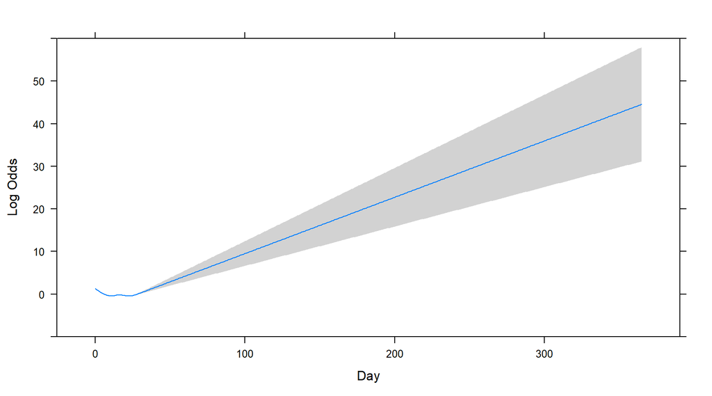

```r
dayProfile <- Predict(
  rcsFit,
  ##Specify the range of the plot variable
  Day = 0:365,
  ##Flip the prediction to get the model for successful grants
  fun = function(x) -x
)
plot(dayProfile, ylab = "Log Odds")
```

For a large set of predictors, the formula method for specifying models is cumbersome. For logistic regression, `train` provides an interface to the glm function that bypasses a model formula, directly produces class predictions, and calculates the area under the ROC curve and other metrics.

Before fitting the model, add the squared day of year variable to the data set.

```r
training$Day2 <- training$Day^2
fullSet <- c(fullSet, "Day2")
reducedSet <- c(reducedSet, "Day2")

set.seed(476)
lrFull <- ?train(
  training[,fullSet],
  y = training$Class,
  method = "glm",
  metric = "ROC",
  trControl = ctrl
)
lrFull
```

[output not shown]

```
## starting httpd help server ... done
```

Here is the code for the reduced set.

```r
set.seed(476)
lrReduced <- train(
  training[, reducedSet],
  y = training$Class,
  method = "glm",
  metric = "ROC",
  trControl = ctrl
)
lrReduced
```

```
## Generalized Linear Model
##
## 8190 samples
##  253 predictor
##    2 classes: 'successful', 'unsuccessful'
##
## No pre-processing
## Resampling: Repeated Train/Test Splits Estimated (1 reps, 75%)
## Summary of sample sizes: 6633
## Resampling results:
##
##   ROC        Sens       Spec
##   0.8737349  0.7807018  0.8308004
```

Removal of the near-zero variance predictors has a positive effect on the model fit. The predictions for the holdout set (of year 2008 grants) is contained in the sub-object pred.

```r
head(lrReduced$pred)
```

```
##           pred          obs successful unsuccessful rowIndex parameter Resample
## 1   successful   successful  0.9978249  0.002175114     6634      none TrainSet
## 2   successful   successful  0.7717196  0.228280412     6635      none TrainSet
## 3   successful   successful  0.8729387  0.127061298     6636      none TrainSet
## 4   successful   successful  0.9425672  0.057432833     6637      none TrainSet
## 5 unsuccessful unsuccessful  0.4300522  0.569947782     6638      none TrainSet
## 6   successful unsuccessful  0.8708560  0.129144012     6639      none TrainSet
```

Note the column in the output labeled .parameter. When train saves predictions, it does so for every tuning parameter. This column in the output is used to label which model generated the predictions. This version of logistic regression has no tuning parameters, so .parameter has a single value (“none”).

Use this data to calculate the confusion matrix.

```r
confusionMatrix(data = lrReduced$pred$pred, reference = lrReduced$pred$obs)
```

```
## Confusion Matrix and Statistics
##
##               Reference
## Prediction     successful unsuccessful
##   successful          445          167
##   unsuccessful        125          820
##
##                Accuracy : 0.8125
##                  95% CI : (0.7922, 0.8316)
##     No Information Rate : 0.6339
##     P-Value [Acc > NIR] : < 2e-16
##
##                   Kappa : 0.6021
##
##  Mcnemar's Test P-Value : 0.01642
##
##             Sensitivity : 0.7807
##             Specificity : 0.8308
##          Pos Pred Value : 0.7271
##          Neg Pred Value : 0.8677
##              Prevalence : 0.3661
##          Detection Rate : 0.2858
##    Detection Prevalence : 0.3931
##       Balanced Accuracy : 0.8058
##
##        'Positive' Class : successful
##
```

These results match the values shown above for lrReduced. The ROC curve can also be computed and plotted using the pROC package:

```r
library(pROC)
reducedRoc <- roc(
  response = lrReduced$pred$obs,
  predictor = lrReduced$pred$successful,
  levels = rev(levels(lrReduced$pred$obs))
)
```

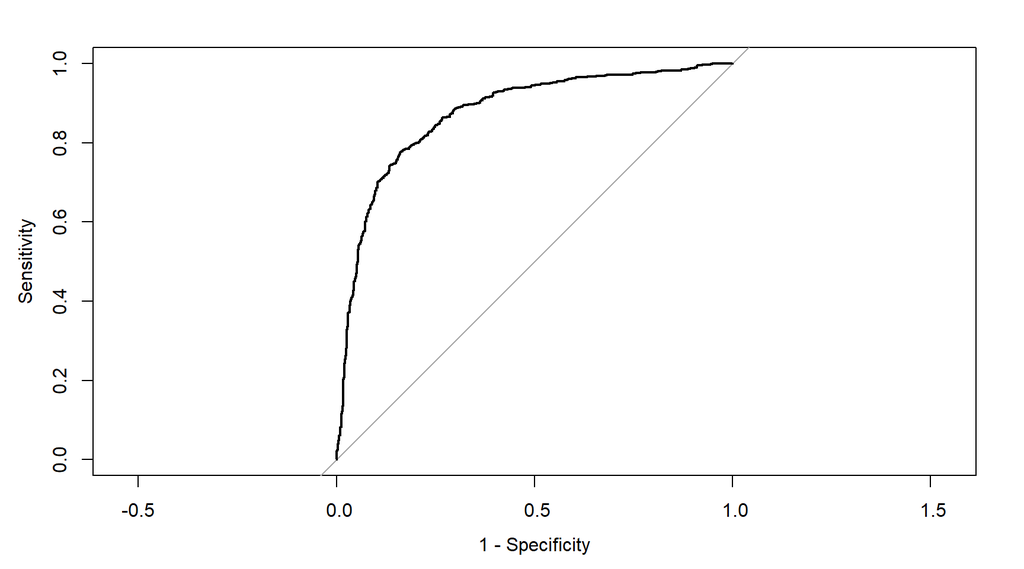

```r
plot(reducedRoc, legacy.axes = TRUE)
```

```r
auc(reducedRoc)
```

```
## Area under the curve: 0.8737
```